# 2022-02-01 Math472.572 Class

R Studio

2/1/2022

# Continuing with Chapter 5 (eBook) on Transformations

In last week’s class we used data about flights out of New York City in 2013

```r
library(tidyverse)
library(nycflights13)
```

and talked about transforming data, in particular we discussed: - **Sorting** data by observation values using `arrange()` - **Rearranging/Removing** variables using `select()` - **Selecting/Removing** observation values using `filter()` - **Creating** new variables using `mutate()` (or `transmute()`)

We ran out of time for one last item related to sorting … that is using built in ranking functions, so we’ll look at this quickly.

## Ranking

`dplyr()` offers some ranking functions: `row_number()`, `dense_rank()`, `percent_rank()`, `cume_dist()`. Explore what these may do with a fairly simple dataframe:

```r
play <- c(4, 1, NA, 5, 2, 3, 2)
```

What is the difference between `row_number()` and `dense_rank()`?

```r
play
```

```
## [1]  4  1 NA  5  2  3  2
```

```r
row_number(play)   # gives the position (1st to nth) of this element when put
```

```
## [1]  5  1 NA  6  2  4  3
```

```r
                   #   in ascending order
dense_rank(play)   # gives the position (1st to nth) of this distinct element
```

```
## [1]  4  1 NA  5  2  3  2
```

```r
                   #   value when put in ascending order (ties get same value)
percent_rank(play) # percent of distinct values that are less than this element
```

```
## [1] 0.8 0.0  NA 1.0 0.2 0.6 0.2
```

```r
                   #   value
cume_dist(play)    # percent of (all, so double count repeats) values that are
```

```
## [1] 0.8333333 0.1666667        NA 1.0000000 0.5000000 0.6666667 0.5000000
```

```r
                   #   LESS than or EQUAL to this value
```

### Some Excercises from the Text

5.5.2 Exercises

4. Find the 10 most delayed flights using a ranking function. How do you want to handle ties? Carefully read the documentation for `min_rank()`.

```r
just_dep_delay <- select(flights, dep_delay)
head(min_rank(just_dep_delay), 10)
```

```
## dep_delay      <NA>      <NA>      <NA>      <NA>      <NA>      <NA>      <NA>
##    208140    219823    208140    164763     48888     94410     69589    119029
##      <NA>      <NA>
##    119029    143247
```

```r
head(arrange(flights, desc(dep_delay)))
```

```
## # A tibble: 6 × 19
##    year month   day dep_time sched_dep_time dep_delay arr_time sched_arr_time
##   <int> <int> <int>    <int>          <int>     <dbl>    <int>          <int>
## 1  2013     1     9      641            900      1301     1242           1530
## 2  2013     6    15     1432           1935      1137     1607           2120
## 3  2013     1    10     1121           1635      1126     1239           1810
## 4  2013     9    20     1139           1845      1014     1457           2210
## 5  2013     7    22      845           1600      1005     1044           1815
## 6  2013     4    10     1100           1900       960     1342           2211
## # … with 11 more variables: arr_delay <dbl>, carrier <chr>, flight <int>,
## #   tailnum <chr>, origin <chr>, dest <chr>, air_time <dbl>, distance <dbl>,
## #   hour <dbl>, minute <dbl>, time_hour <dttm>
```

5. What does 1:3 + 1:10 return? Why?

```r
1:3 + 1:10
```

```
##  [1]  2  4  6  5  7  9  8 10 12 11
```

## Using `summarize()`

When we summarize, we will typically generate statistics associated with the data. Perhaps means, standard deviations, medians, IQR’s, minimum values, maximum values, sums, numbers of elements, or numbers of distinct elements for instance. We’ll often be interested in summarizing our data with respect to different key features, and thus we may opt to group our data (conceptually) before applying the `summarize()`

```r
flights_by_carrier <- group_by(flights, carrier)
summarize(flights_by_carrier, avg_dep_delay = mean(dep_delay))
```

```
## # A tibble: 16 × 2
##    carrier avg_dep_delay
##    <chr>           <dbl>
##  1 9E              NA
##  2 AA              NA
##  3 AS              NA
##  4 B6              NA
##  5 DL              NA
##  6 EV              NA
##  7 F9              NA
##  8 FL              NA
##  9 HA               4.90
## 10 MQ              NA
## 11 OO              NA
## 12 UA              NA
## 13 US              NA
## 14 VX              NA
## 15 WN              NA
## 16 YV              NA
```

```r
    # there were some dep_delay with NA. Arithemetic with NA often gives NA.

# Ignoring the NA's, in the mean, add option "na.rm = TRUE"
carrier_delays <- summarize(flights_by_carrier, avg_dep_delay = mean(dep_delay, na.rm = TRUE))

# Let's arrange it from largest delay to smallest delay (worst to best)
arrange(carrier_delays, desc(avg_dep_delay))
```

```
## # A tibble: 16 × 2
##    carrier avg_dep_delay
##    <chr>           <dbl>
##  1 F9              20.2
##  2 EV              20.0
##  3 YV              19.0
##  4 FL              18.7
##  5 WN              17.7
##  6 9E              16.7
##  7 B6              13.0
##  8 VX              12.9
##  9 OO              12.6
## 10 UA              12.1
## 11 MQ              10.6
## 12 DL               9.26
## 13 AA               8.59
## 14 AS               5.80
## 15 HA               4.90
## 16 US               3.78
```

```r
# Suppose we only want to consider the positive delays (no negatives to counter balance?)
flights %>% group_by(carrier) %>% filter(dep_delay >= 0) %>% summarize(avg_dep_delay = mean(dep_delay)) %>% arrange(desc(avg_dep_delay))
```

```
## # A tibble: 16 × 2
##    carrier avg_dep_delay
##    <chr>           <dbl>
##  1 OO               58
##  2 YV               49.2
##  3 EV               47.0
##  4 9E               44.9
##  5 F9               40.0
##  6 MQ               38.6
##  7 FL               37.8
##  8 HA               37.3
##  9 B6               35.2
## 10 AA               32.1
## 11 DL               31.5
## 12 WN               30.3
## 13 US               29.2
## 14 VX               29.1
## 15 AS               27.9
## 16 UA               26.6
```

Suppose you want to get an idea of the performance of each carrier in terms of the average delay in departure time? First we want to group our flights dataset by carrier. What is the output of this command? NOTE: We can only group by variable, not observation values.

#### Some Exercises from the

[Text](https://r4ds.had.co.nz/transform.html#exercises-12)

4. Look at the number of cancelled flights per day. Is there a pattern? Is the proportion of cancelled flights related to the average delay?

```r
nrow(filter(flights, is.na(air_time)))
```

```
## [1] 9430
```

```r
cancelled <- group_by(flights, day, month, year) %>% summarize(num_cancelled = sum(is.na(air_time)), avg_delay = mean(dep_delay, na.rm = TRUE)) %>% arrange(year, month, day)
```

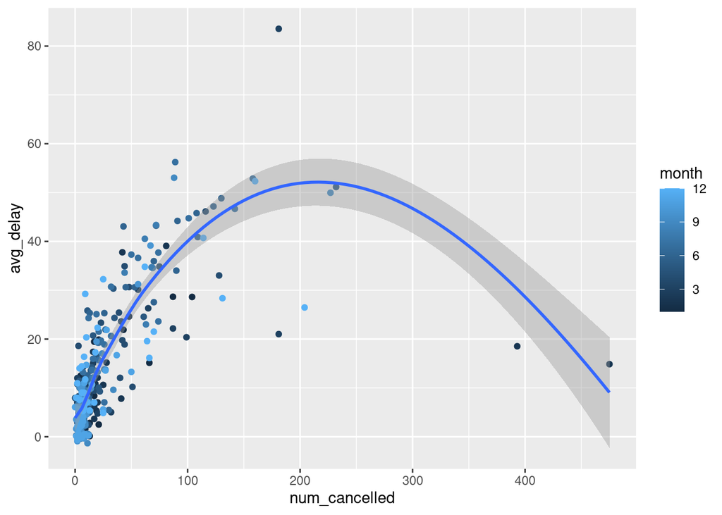

```r
ggplot(data = cancelled) +
  geom_point(mapping = aes(x = num_cancelled, y = avg_delay, color = month)) +
  geom_smooth(mapping = aes(x = num_cancelled, y = avg_delay))
```

4(special) Dr. McNelis wants to know if you can find a relatively simple way to determine the number of “NA” entries for the following variables of our flights data: dep_time, dep_delay, arr_time, arr_delay, tail_num, air_time (or of all variables in flights if that is faster). Feel free to Google as well. Is there anything you find that is interesting or curious?

```r
nrow(filter(flights, is.na(dep_time)))
```

```
## [1] 8255
```

```r
nrow(filter(flights, is.na(dep_delay)))
```

```
## [1] 8255
```

```r
nrow(filter(flights, is.na(arr_time)))
```

```
## [1] 8713
```

```r
nrow(filter(flights, is.na(arr_delay)))
```

```
## [1] 9430
```

```r
nrow(filter(flights, is.na(tailnum)))
```

```
## [1] 2512
```

```r
nrow(filter(flights, is.na(air_time)))
```

```
## [1] 9430
```

5. You’ve looked at which carrier has the worst delays. Challenge: can you disentangle the effects of bad airports vs. bad carriers? Why/why not? (Hint: think about `flights %>% group_by(carrier, dest) %>% summarise(n())`)

```r
(amount_delays <- flights %>% group_by(carrier, origin) %>% summarise(count = n()))
```

```
## # A tibble: 35 × 3
## # Groups:   carrier [16]
##    carrier origin count
##    <chr>   <chr>  <int>
##  1 9E      EWR     1268
##  2 9E      JFK    14651
##  3 9E      LGA     2541
##  4 AA      EWR     3487
##  5 AA      JFK    13783
##  6 AA      LGA    15459
##  7 AS      EWR      714
##  8 B6      EWR     6557
##  9 B6      JFK    42076
## 10 B6      LGA     6002
## # … with 25 more rows
```

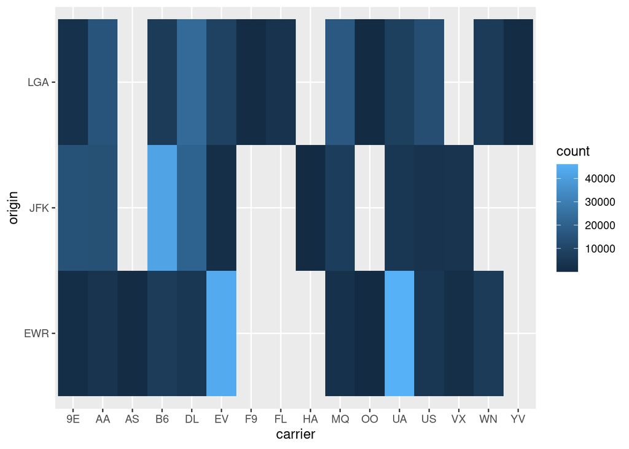

```r
ggplot(data = amount_delays) +
  geom_bin2d(mapping = aes(x = carrier, y = origin, fill = count))
```

#### Putting things together, more exercises from the

[text](https://r4ds.had.co.nz/transform.html#exercises-13)

3. What time of day should you fly if you want to avoid delays as much as possible?

```r
delay_by_hour <- group_by(flights, sched_dep_time) %>% summarize(avg_delay = mean(dep_delay, na.rm = TRUE))

arrange(delay_by_hour, avg_delay)
```

```
## # A tibble: 1,021 × 2
##    sched_dep_time avg_delay
##             <int>     <dbl>
##  1           2201     -7
##  2            516     -5
##  3           2158     -4
##  4            913     -3.83
##  5            931     -3.58
##  6            711     -3.25
##  7            500     -3.14
##  8           1058     -3.1
##  9            501     -3
## 10           1424     -3
## # … with 1,011 more rows
```

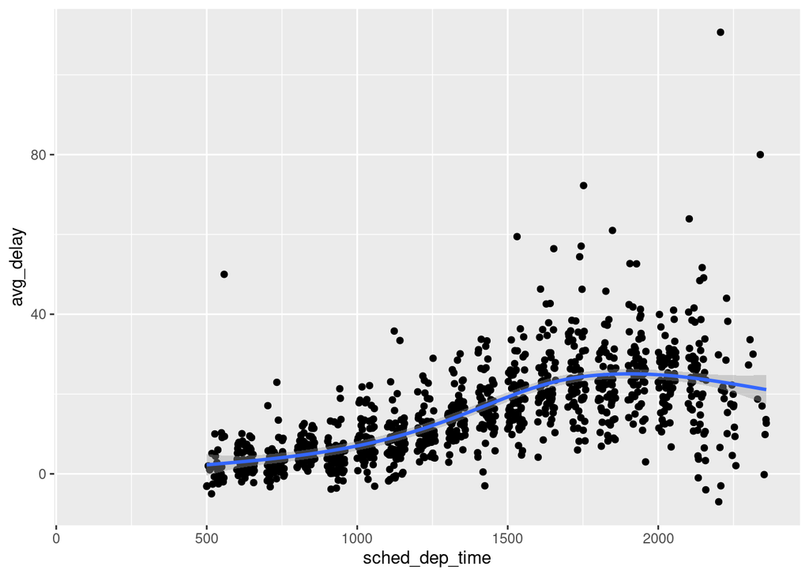

```r
ggplot(delay_by_hour) +
  geom_point(mapping = aes(x = sched_dep_time, y = avg_delay,))+
  geom_smooth(mapping = aes(x = sched_dep_time, y = avg_delay))
```

4. For each destination, compute the total minutes of delay. For each flight, compute the proportion of the total delay for its destination.
5. Find all destinations that are flown by at least two carriers. Use that information to rank the carriers.
6. For each plane (i.e. tail number), count the number of flights before the first delay of greater than 1 hour.

# Exploratory Data Analysis

Putting it all together. You’re going to be working with a new data set and from it you’ll want to explore the data, try to ask questions about your data, search for answers using the tools in your toolbox now. As you do this, can you refine your questions?

How might you start? Try asking yourself: